# Logistical Regression Project

In this project we will be working with the UCI adult dataset. We will be attempting to predict if people in the data set belong in a certain class by salary, either making <=50k or >50k per year.

Typically most of your time is spent cleaning data, not running the few lines of code that build your model, this project will try to reflect that by showing different issues that may arise when cleaning data.

## Get the Data

Read in the adult_sal.csv file and set it to a data frame called adult.

```r
library(readr)
adult <- read.csv('Training Exercises/Machine Learning Projects/CSV files for ML Projects/adult_sal.csv')
head(adult)
```

|  | X | age | type_employer | fnlwgt | education | education_num | marital | occupation | relationship | race | sex | capital_gain | capital_loss | hr_per_week | country | income |
| --- | --- | --- | --- | --- | --- | --- | --- | --- | --- | --- | --- | --- | --- | --- | --- | --- |
| 1 | 1 | 39 | State-gov | 77516 | Bachelors | 13 | Never-married | Adm-clerical | Not-in-family | White | Male | 2174 | 0 | 40 | United-States | <=50K |
| 2 | 2 | 50 | Self-emp-not-inc | 83311 | Bachelors | 13 | Married-civ-spouse | Exec-managerial | Husband | White | Male | 0 | 0 | 13 | United-States | <=50K |
| 3 | 3 | 38 | Private | 215646 | HS-grad | 9 | Divorced | Handlers-cleaners | Not-in-family | White | Male | 0 | 0 | 40 | United-States | <=50K |
| 4 | 4 | 53 | Private | 234721 | 11th | 7 | Married-civ-spouse | Handlers-cleaners | Husband | Black | Male | 0 | 0 | 40 | United-States | <=50K |
| 5 | 5 | 28 | Private | 338409 | Bachelors | 13 | Married-civ-spouse | Prof-specialty | Wife | Black | Female | 0 | 0 | 40 | Cuba | <=50K |
| 6 | 6 | 37 | Private | 284582 | Masters | 14 | Married-civ-spouse | Exec-managerial | Wife | White | Female | 0 | 0 | 40 | United-States | <=50K |

Drop the repeated index column

```r
library(dplyr)
adult <- adult %>% select(-X)
head(adult)
```

|  | age | type_employer | fnlwgt | education | education_num | marital | occupation | relationship | race | sex | capital_gain | capital_loss | hr_per_week | country | income |
| --- | --- | --- | --- | --- | --- | --- | --- | --- | --- | --- | --- | --- | --- | --- | --- |
| 1 | 39 | State-gov | 77516 | Bachelors | 13 | Never-married | Adm-clerical | Not-in-family | White | Male | 2174 | 0 | 40 | United-States | <=50K |
| 2 | 50 | Self-emp-not-inc | 83311 | Bachelors | 13 | Married-civ-spouse | Exec-managerial | Husband | White | Male | 0 | 0 | 13 | United-States | <=50K |
| 3 | 38 | Private | 215646 | HS-grad | 9 | Divorced | Handlers-cleaners | Not-in-family | White | Male | 0 | 0 | 40 | United-States | <=50K |
| 4 | 53 | Private | 234721 | 11th | 7 | Married-civ-spouse | Handlers-cleaners | Husband | Black | Male | 0 | 0 | 40 | United-States | <=50K |
| 5 | 28 | Private | 338409 | Bachelors | 13 | Married-civ-spouse | Prof-specialty | Wife | Black | Female | 0 | 0 | 40 | Cuba | <=50K |
| 6 | 37 | Private | 284582 | Masters | 14 | Married-civ-spouse | Exec-managerial | Wife | White | Female | 0 | 0 | 40 | United-States | <=50K |

Check the head,str, and summary of the data now.

```r
str(adult)
```

```
'data.frame':   32561 obs. of  15 variables:
 $ age          : int  39 50 38 53 28 37 49 52 31 42 ...
 $ type_employer: Factor w/ 9 levels "?","Federal-gov",..: 8 7 5 5 5 5 5 7 5 5 ...
 $ fnlwgt       : int  77516 83311 215646 234721 338409 284582 160187 209642 45781 159449 ...
 $ education    : Factor w/ 16 levels "10th","11th",..: 10 10 12 2 10 13 7 12 13 10 ...
 $ education_num: int  13 13 9 7 13 14 5 9 14 13 ...
 $ marital      : Factor w/ 7 levels "Divorced","Married-AF-spouse",..: 5 3 1 3 3 3 4 3 5 3 ...
 $ occupation   : Factor w/ 15 levels "?","Adm-clerical",..: 2 5 7 7 11 5 9 5 11 5 ...
 $ relationship : Factor w/ 6 levels "Husband","Not-in-family",..: 2 1 2 1 6 6 2 1 2 1 ...
 $ race         : Factor w/ 5 levels "Amer-Indian-Eskimo",..: 5 5 5 3 3 5 3 5 5 5 ...
 $ sex          : Factor w/ 2 levels "Female","Male": 2 2 2 2 1 1 1 2 1 2 ...
 $ capital_gain : int  2174 0 0 0 0 0 0 0 14084 5178 ...
 $ capital_loss : int  0 0 0 0 0 0 0 0 0 0 ...
 $ hr_per_week  : int  40 13 40 40 40 40 16 45 50 40 ...
 $ country      : Factor w/ 42 levels "?","Cambodia",..: 40 40 40 40 6 40 24 40 40 40 ...
 $ income       : Factor w/ 2 levels "<=50K",">50K": 1 1 1 1 1 1 1 2 2 2 ...
```

```r
summary(adult)
```

```
      age                 type_employer       fnlwgt               education     education_num
 Min.   :17.00   Private         :22696   Min.   :  12285   HS-grad     :10501   Min.   : 1.00
 1st Qu.:28.00   Self-emp-not-inc: 2541   1st Qu.: 117827   Some-college: 7291   1st Qu.: 9.00
 Median :37.00   Local-gov       : 2093   Median : 178356   Bachelors   : 5355   Median :10.00
 Mean   :38.58   ?               : 1836   Mean   : 189778   Masters     : 1723   Mean   :10.08
 3rd Qu.:48.00   State-gov       : 1298   3rd Qu.: 237051   Assoc-voc   : 1382   3rd Qu.:12.00
 Max.   :90.00   Self-emp-inc    : 1116   Max.   :1484705   11th        : 1175   Max.   :16.00
                 (Other)         :  981                     (Other)     : 5134
                  marital                occupation           relationship                   race
 Divorced             : 4443   Prof-specialty :4140   Husband       :13193   Amer-Indian-Eskimo:  311
 Married-AF-spouse    :   23   Craft-repair   :4099   Not-in-family : 8305   Asian-Pac-Islander: 1039
 Married-civ-spouse   :14976   Exec-managerial:4066   Other-relative:  981   Black             : 3124
 Married-spouse-absent:  418   Adm-clerical   :3770   Own-child     : 5068   Other             :  271
 Never-married        :10683   Sales          :3650   Unmarried     : 3446   White             :27816
 Separated            : 1025   Other-service  :3295   Wife          : 1568
 Widowed              :  993   (Other)        :9541
     sex         capital_gain    capital_loss     hr_per_week             country        income
 Female:10771   Min.   :    0   Min.   :   0.0   Min.   : 1.00   United-States:29170   <=50K:24720
 Male  :21790   1st Qu.:    0   1st Qu.:   0.0   1st Qu.:40.00   Mexico       :  643   >50K : 7841
                Median :    0   Median :   0.0   Median :40.00   ?            :  583
                Mean   : 1078   Mean   :  87.3   Mean   :40.44   Philippines  :  198
                3rd Qu.:    0   3rd Qu.:   0.0   3rd Qu.:45.00   Germany      :  137
                Max.   :99999   Max.   :4356.0   Max.   :99.00   Canada       :  121
                                                                 (Other)      : 1709
```

Some questions I have after analysing the `str()` and `summary()`: * What is `fnlwgt`? * What is `education_num`? * What are `capital_gain` and `capital_loss`?

## Data Cleaning

Notice that we have a lot of columns that are cateogrical factors, however a lot of these columns have too many factors than may be necessary. In this data cleaning section we’ll try to clean these columns up by reducing the number of factors.

type_employer column Use table() to check out the frequency of the type_employer column.

```r
table(adult$type_employer)
```

```
               ?      Federal-gov        Local-gov     Never-worked          Private     Self-emp-inc
            1836              960             2093                7            22696             1116
Self-emp-not-inc        State-gov      Without-pay
            2541             1298               14
```

Combine the two smallest groups (`Never-worked` and `Without-pay` into a single group called “Unemployed”.

```r
#help(sapply)
unemp <- function(job){
    job <- as.character(job)
    if (job=='Never-worked' | job=='Without-pay'){
        return('Unemployed')
    }else{
        return(job)
    }
}
adult$type_employer <- sapply(adult$type_employer,unemp)
table(adult$type_employer)
```

```
               ?      Federal-gov        Local-gov          Private     Self-emp-inc Self-emp-not-inc
            1836              960             2093            22696             1116             2541
       State-gov       Unemployed
            1298               21
```

What other columns are suitable for combining? Combine State and Local gov jobs into a category called SL-gov and combine self-employed jobs into a category called self-emp.

```r
gov <- function(job) {
  job <- as.character(job)
  if (job=='Local-gov' | job=='State-gov') {
    return('SL-gov')
  }
  else {return(job)}
}
adult$type_employer <- sapply(adult$type_employer,gov)
table(adult$type_employer)
```

```
               ?      Federal-gov          Private     Self-emp-inc Self-emp-not-inc           SL-gov
            1836              960            22696             1116             2541             3391
      Unemployed
              21
```

```r
self <- function(job) {
  job <- as.character(job)
  if (job=='Self-emp-inc' | job=='Self-emp-not-inc') {
    return('Self-emp')
  }
  else {return(job)}
}
adult$type_employer <- sapply(adult$type_employer,self)
table(adult$type_employer)
```

```
          ? Federal-gov     Private    Self-emp      SL-gov  Unemployed
       1836         960       22696        3657        3391          21
```

Marital Column Use table() to look at the marital column

```r
table(adult$marital)
```

```
             Divorced     Married-AF-spouse    Married-civ-spouse Married-spouse-absent
                 4443                    23                 14976                   418
        Never-married             Separated               Widowed
                10683                  1025                   993
```

Reduce this to three groups:

Married Not-Married Never-Married

```r
marr <- function(marital) {
  marital <- as.character(marital)
  if (marital=='Divorced' | marital=='Separated' | marital=='Widowed') {
    return('Not-married')
  }
  else if (marital=='Never-married') {
  return('Never-married')
  }
  else {return('Married')}
}
adult$marital <- sapply(adult$marital,marr)
table(adult$marital)
```

```
      Married Never-married   Not-married
        15417         10683          6461
```

Country Column Check the country column using table()

```r
table(adult$country)
```

```
                         ?                   Cambodia                     Canada
                       583                         19                        121
                     China                   Columbia                       Cuba
                        75                         59                         95
        Dominican-Republic                    Ecuador                El-Salvador
                        70                         28                        106
                   England                     France                    Germany
                        90                         29                        137
                    Greece                  Guatemala                      Haiti
                        29                         64                         44
        Holand-Netherlands                   Honduras                       Hong
                         1                         13                         20
                   Hungary                      India                       Iran
                        13                        100                         43
                   Ireland                      Italy                    Jamaica
                        24                         73                         81
                     Japan                       Laos                     Mexico
                        62                         18                        643
                 Nicaragua Outlying-US(Guam-USVI-etc)                       Peru
                        34                         14                         31
               Philippines                     Poland                   Portugal
                       198                         60                         37
               Puerto-Rico                   Scotland                      South
                       114                         12                         80
                    Taiwan                   Thailand            Trinadad&Tobago
                        51                         18                         19
             United-States                    Vietnam                 Yugoslavia
                     29170                         67                         16
```

Group these countries together however you see fit. You have flexibility here because there is no right/wrong way to do this, possibly group by continents. You should be able to reduce the number of groups here significantly though.

```r
# ideas - Europe, North America, South America, etc. I don't actually know which continent each country goes in, but it will be easy to find out.

# first, create vectors of each continent
europe <- c('England', 'France', 'Holand-Netherlands','Hungary', 'Greece', 'Ireland', 'Italy', 'Poland', 'Scotland', 'Germany', 'Portugal', 'Yugoslavia')
asia <- c('China', 'Philippines', 'Taiwan', 'Cambodia', 'India', 'Laos', 'Thailand', 'Vietnam', 'Japan')
americas <- c('Dominican-Republic','Nicaragua', 'Puerto-Rico', 'United-States', 'Columbia', 'Ecuador', 'Guatemala', 'Honduras', 'Trinidad&Tobago', 'Peru', 'Mexico','Jamaica','Haiti','El-Salvador','Cuba', 'Canada')



# second, write a function that iterates through each item in adult$country and checks if it is in one of the vectors. If yes, reassign the value for that item to the name of the continent.
continent <- function(country) {
  country <- as.character(country)
  if (country %in% europe) {
    return('Europe')
  }
  else if (country %in% asia) {
    return('Asia')
  }
  else if (country %in% americas) {
    return('Americas')
  }
  else {return('Other')}
}

# call the function
adult$country <- sapply(adult$country,continent)


# given that we've just put all the countries into continents, we should change the name of the column
adult <- adult %>% rename(continent=country)
table(adult$continent)
```

```
Americas     Asia   Europe    Other
   30673      608      521      759
```

Check the str() of adult again. Make sure any of the columns we changed have factor levels with factor()

```r
str(adult)
```

```
'data.frame':   32561 obs. of  15 variables:
 $ age          : int  39 50 38 53 28 37 49 52 31 42 ...
 $ type_employer: chr  "SL-gov" "Self-emp" "Private" "Private" ...
 $ fnlwgt       : int  77516 83311 215646 234721 338409 284582 160187 209642 45781 159449 ...
 $ education    : Factor w/ 16 levels "10th","11th",..: 10 10 12 2 10 13 7 12 13 10 ...
 $ education_num: int  13 13 9 7 13 14 5 9 14 13 ...
 $ marital      : chr  "Never-married" "Married" "Not-married" "Married" ...
 $ occupation   : Factor w/ 15 levels "?","Adm-clerical",..: 2 5 7 7 11 5 9 5 11 5 ...
 $ relationship : Factor w/ 6 levels "Husband","Not-in-family",..: 2 1 2 1 6 6 2 1 2 1 ...
 $ race         : Factor w/ 5 levels "Amer-Indian-Eskimo",..: 5 5 5 3 3 5 3 5 5 5 ...
 $ sex          : Factor w/ 2 levels "Female","Male": 2 2 2 2 1 1 1 2 1 2 ...
 $ capital_gain : int  2174 0 0 0 0 0 0 0 14084 5178 ...
 $ capital_loss : int  0 0 0 0 0 0 0 0 0 0 ...
 $ hr_per_week  : int  40 13 40 40 40 40 16 45 50 40 ...
 $ continent    : chr  "Americas" "Americas" "Americas" "Americas" ...
 $ income       : Factor w/ 2 levels "<=50K",">50K": 1 1 1 1 1 1 1 2 2 2 ...
```

We can see that they are still characters, so let’s change them to factors

```r
adult$type_employer <- sapply(adult$type_employer,factor)
adult$continent <- sapply(adult$continent,factor)
adult$marital <- sapply(adult$marital,factor)
```

```r
str(adult)
```

```
'data.frame':   32561 obs. of  15 variables:
 $ age          : int  39 50 38 53 28 37 49 52 31 42 ...
 $ type_employer: Factor w/ 6 levels "SL-gov","Self-emp",..: 1 2 3 3 3 3 3 2 3 3 ...
 $ fnlwgt       : int  77516 83311 215646 234721 338409 284582 160187 209642 45781 159449 ...
 $ education    : Factor w/ 16 levels "10th","11th",..: 10 10 12 2 10 13 7 12 13 10 ...
 $ education_num: int  13 13 9 7 13 14 5 9 14 13 ...
 $ marital      : Factor w/ 3 levels "Never-married",..: 1 2 3 2 2 2 2 2 1 2 ...
 $ occupation   : Factor w/ 15 levels "?","Adm-clerical",..: 2 5 7 7 11 5 9 5 11 5 ...
 $ relationship : Factor w/ 6 levels "Husband","Not-in-family",..: 2 1 2 1 6 6 2 1 2 1 ...
 $ race         : Factor w/ 5 levels "Amer-Indian-Eskimo",..: 5 5 5 3 3 5 3 5 5 5 ...
 $ sex          : Factor w/ 2 levels "Female","Male": 2 2 2 2 1 1 1 2 1 2 ...
 $ capital_gain : int  2174 0 0 0 0 0 0 0 14084 5178 ...
 $ capital_loss : int  0 0 0 0 0 0 0 0 0 0 ...
 $ hr_per_week  : int  40 13 40 40 40 40 16 45 50 40 ...
 $ continent    : Factor w/ 4 levels "Americas","Asia",..: 1 1 1 1 1 1 1 1 1 1 ...
 $ income       : Factor w/ 2 levels "<=50K",">50K": 1 1 1 1 1 1 1 2 2 2 ...
```

```r
table(adult$education)
```

```
        10th         11th         12th      1st-4th      5th-6th      7th-8th          9th   Assoc-acdm
         933         1175          433          168          333          646          514         1067
   Assoc-voc    Bachelors    Doctorate      HS-grad      Masters    Preschool  Prof-school Some-college
        1382         5355          413        10501         1723           51          576         7291
```

Missing Data Notice how we have data that is missing.

Amelia Install and load the Amelia package.

```r
library(Amelia)
adult[adult=='?'] <- NA

table(adult$type_employer)
```

```
     SL-gov    Self-emp     Private Federal-gov           ?  Unemployed
       3391        3657       22696         960           0          21
```

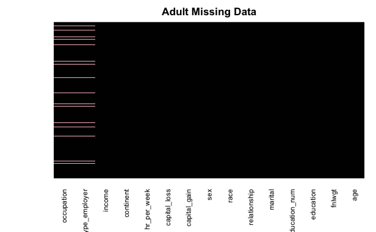

```r
missmap(adult, main='Adult Missing Data', y.at=c(1), y.labels = c(''), col=c('pink', 'black'), legend=F)
```

Get rid of the missing data

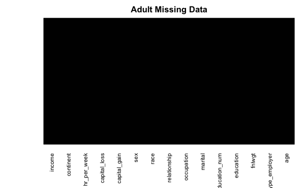

```r
adult <- na.omit(adult)
missmap(adult, main='Adult Missing Data', y.at=c(1), y.labels = c(''), col=c('pink', 'black'), legend=F)
```

## Exploratory Data Analysis (EDA)

```r
str(adult)
```

```
'data.frame':   30718 obs. of  15 variables:
 $ age          : int  39 50 38 53 28 37 49 52 31 42 ...
 $ type_employer: Factor w/ 6 levels "SL-gov","Self-emp",..: 1 2 3 3 3 3 3 2 3 3 ...
 $ fnlwgt       : int  77516 83311 215646 234721 338409 284582 160187 209642 45781 159449 ...
 $ education    : Factor w/ 16 levels "10th","11th",..: 10 10 12 2 10 13 7 12 13 10 ...
 $ education_num: int  13 13 9 7 13 14 5 9 14 13 ...
 $ marital      : Factor w/ 3 levels "Never-married",..: 1 2 3 2 2 2 2 2 1 2 ...
 $ occupation   : Factor w/ 15 levels "?","Adm-clerical",..: 2 5 7 7 11 5 9 5 11 5 ...
 $ relationship : Factor w/ 6 levels "Husband","Not-in-family",..: 2 1 2 1 6 6 2 1 2 1 ...
 $ race         : Factor w/ 5 levels "Amer-Indian-Eskimo",..: 5 5 5 3 3 5 3 5 5 5 ...
 $ sex          : Factor w/ 2 levels "Female","Male": 2 2 2 2 1 1 1 2 1 2 ...
 $ capital_gain : int  2174 0 0 0 0 0 0 0 14084 5178 ...
 $ capital_loss : int  0 0 0 0 0 0 0 0 0 0 ...
 $ hr_per_week  : int  40 13 40 40 40 40 16 45 50 40 ...
 $ continent    : Factor w/ 4 levels "Americas","Asia",..: 1 1 1 1 1 1 1 1 1 1 ...
 $ income       : Factor w/ 2 levels "<=50K",">50K": 1 1 1 1 1 1 1 2 2 2 ...
 - attr(*, "na.action")= 'omit' Named int  28 62 70 78 107 129 150 155 161 188 ...
  ..- attr(*, "names")= chr  "28" "62" "70" "78" ...
```

Use ggplot2 to create a histogram of ages, colored by income.

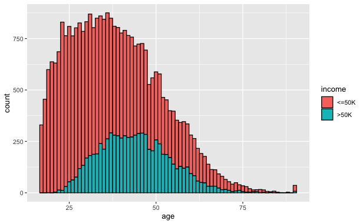

```r
library(ggplot2)
library(ggthemes)
library(plotly)

ggplot(adult, aes(x=age)) + geom_histogram(aes(fill=income), col='black', binwidth = 1)
```

Plot a histogram of hours worked per week

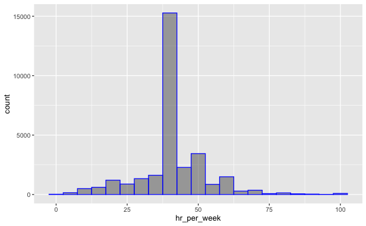

```r
ggplot(adult, aes(x=hr_per_week)) + geom_histogram(binwidth=5, color='blue', alpha=0.5)
```

Create a barplot of continent with the fill color defined by income class. Optional: Figure out how rotate the x axis text for readability

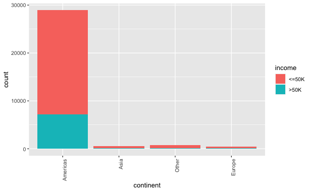

```r
ggplot(adult, aes(x=continent)) + geom_bar(aes(fill=income)) + theme(axis.text.x = element_text(angle = 90, hjust = 1))
```

## Building a Model

Now it’s time to build a model to classify people into two groups: Above or Below 50k in Salary.

Logistic Regression Refer to the Lecture or ISLR if you are fuzzy on any of this.

Logistic Regression is a type of classification model. In classification models, we attempt to predict the outcome of categorical dependent variables, using one or more independent variables. The independent variables can be either categorical or numerical.

Logistic regression is based on the logistic function, which always takes values between 0 and 1. Replacing the dependent variable of the logistic function with a linear combination of dependent variables we intend to use for regression, we arrive at the formula for logistic regression.

Take a quick look at the head() of adult to make sure we have a good overview before going into building the model!

```r
head(adult)
```

|  | age | type_employer | fnlwgt | education | education_num | marital | occupation | relationship | race | sex | capital_gain | capital_loss | hr_per_week | continent | income |
| --- | --- | --- | --- | --- | --- | --- | --- | --- | --- | --- | --- | --- | --- | --- | --- |
| 1 | 39 | SL-gov | 77516 | Bachelors | 13 | Never-married | Adm-clerical | Not-in-family | White | Male | 2174 | 0 | 40 | Americas | <=50K |
| 2 | 50 | Self-emp | 83311 | Bachelors | 13 | Married | Exec-managerial | Husband | White | Male | 0 | 0 | 13 | Americas | <=50K |
| 3 | 38 | Private | 215646 | HS-grad | 9 | Not-married | Handlers-cleaners | Not-in-family | White | Male | 0 | 0 | 40 | Americas | <=50K |
| 4 | 53 | Private | 234721 | 11th | 7 | Married | Handlers-cleaners | Husband | Black | Male | 0 | 0 | 40 | Americas | <=50K |
| 5 | 28 | Private | 338409 | Bachelors | 13 | Married | Prof-specialty | Wife | Black | Female | 0 | 0 | 40 | Americas | <=50K |
| 6 | 37 | Private | 284582 | Masters | 14 | Married | Exec-managerial | Wife | White | Female | 0 | 0 | 40 | Americas | <=50K |

## Train Test Split

Split the data into a train and test set using the caTools library as done in previous lectures.

```r
library(caTools)
# Set a random see so your "random" results are the same as this notebook
set.seed(101)

# Split up the sample, basically randomly assigns a booleans to a new column "sample"
sample <- sample.split(adult$income, SplitRatio = 0.70) # SplitRatio = percent of sample==TRUE

# Training Data
train = subset(adult, sample == TRUE)

# Testing Data
test = subset(adult, sample == FALSE)
```

```r
# generalized linear model
logModel <- glm(formula=income ~ . , family = binomial(link='logit'),data = train)
```

```
glm.fit: fitted probabilities numerically 0 or 1 occurred
```

```r
summary(logModel)
```

```
Call:
glm(formula = income ~ ., family = binomial(link = "logit"),
    data = train)

Deviance Residuals:
    Min       1Q   Median       3Q      Max
-5.1166  -0.5169  -0.1977   0.0000   3.5185

Coefficients: (1 not defined because of singularities)
                              Estimate Std. Error z value Pr(>|z|)
(Intercept)                 -7.342e+00  4.238e-01 -17.324  < 2e-16 ***
age                          2.562e-02  2.004e-03  12.785  < 2e-16 ***
type_employerSelf-emp        1.977e-03  8.997e-02   0.022  0.98247
type_employerPrivate         2.319e-01  7.316e-02   3.170  0.00153 **
type_employerFederal-gov     6.825e-01  1.267e-01   5.388 7.12e-08 ***
type_employerUnemployed     -1.345e+01  3.684e+02  -0.037  0.97087
fnlwgt                       4.628e-07  2.071e-07   2.234  0.02547 *
education11th                1.978e-01  2.568e-01   0.770  0.44114
education12th                3.352e-01  3.398e-01   0.987  0.32385
education1st-4th            -7.073e-01  5.966e-01  -1.185  0.23586
education5th-6th            -2.746e-01  3.919e-01  -0.701  0.48350
education7th-8th            -5.291e-01  2.876e-01  -1.840  0.06576 .
education9th                -7.413e-02  3.184e-01  -0.233  0.81590
educationAssoc-acdm          1.253e+00  2.164e-01   5.791 6.99e-09 ***
educationAssoc-voc           1.454e+00  2.083e-01   6.982 2.91e-12 ***
educationBachelors           2.004e+00  1.936e-01  10.350  < 2e-16 ***
educationDoctorate           2.867e+00  2.633e-01  10.888  < 2e-16 ***
educationHS-grad             8.368e-01  1.888e-01   4.433 9.29e-06 ***
educationMasters             2.344e+00  2.062e-01  11.367  < 2e-16 ***
educationPreschool          -1.934e+01  1.645e+02  -0.118  0.90640
educationProf-school         2.792e+00  2.467e-01  11.319  < 2e-16 ***
educationSome-college        1.203e+00  1.914e-01   6.287 3.23e-10 ***
education_num                       NA         NA      NA       NA
maritalMarried               1.247e+00  1.935e-01   6.446 1.15e-10 ***
maritalNot-married           5.465e-01  9.949e-02   5.494 3.94e-08 ***
occupationArmed-Forces      -6.042e-01  1.846e+00  -0.327  0.74339
occupationCraft-repair       4.297e-02  9.478e-02   0.453  0.65029
occupationExec-managerial    7.705e-01  9.092e-02   8.475  < 2e-16 ***
occupationFarming-fishing   -1.124e+00  1.617e-01  -6.948 3.69e-12 ***
occupationHandlers-cleaners -8.053e-01  1.723e-01  -4.673 2.97e-06 ***
```

[output cut: 19 more lines]

```
capital_loss                 6.574e-04  4.565e-05  14.402  < 2e-16 ***
hr_per_week                  2.921e-02  1.987e-03  14.702  < 2e-16 ***
continentAsia               -6.962e-02  2.216e-01  -0.314  0.75342
continentOther              -3.741e-01  1.533e-01  -2.441  0.01465 *
continentEurope              6.199e-02  1.554e-01   0.399  0.69006
---
Signif. codes:  0 ‘***’ 0.001 ‘**’ 0.01 ‘*’ 0.05 ‘.’ 0.1 ‘ ’ 1

(Dispersion parameter for binomial family taken to be 1)

    Null deviance: 24138  on 21502  degrees of freedom
Residual deviance: 14019  on 21450  degrees of freedom
AIC: 14125

Number of Fisher Scoring iterations: 14
```

We have still a lot of features! Some important, some not so much. R comes with an awesome function called step(). The step() function iteratively tries to remove predictor variables from the model in an attempt to delete variables that do not significantly add to the fit. How does it do this? It uses AIC. Read the wikipedia page for AIC if you want to further understand this, you can also check out help(step). This level of statistics is outside the scope of this project assignment so let’s keep moving along

```r
new.model <- step(logModel)
```

```
Start:  AIC=14125.21
income ~ age + type_employer + fnlwgt + education + education_num +
    marital + occupation + relationship + race + sex + capital_gain +
    capital_loss + hr_per_week + continent
```

[output not shown]

```
Step:  AIC=14125.21
income ~ age + type_employer + fnlwgt + education + marital +
    occupation + relationship + race + sex + capital_gain + capital_loss +
    hr_per_week + continent
```

[output not shown]

```
                Df Deviance   AIC
<none>                14019 14125
- continent      3    14026 14126
- fnlwgt         1    14024 14128
- race           4    14037 14135
- type_employer  4    14065 14163
- marital        2    14074 14176
- sex            1    14112 14216
- age            1    14184 14288
- capital_loss   1    14234 14338
- hr_per_week    1    14240 14344
- relationship   5    14307 14403
- occupation    13    14466 14546
- education     15    14759 14835
- capital_gain   1    15267 15371
```

```r
fitted.probabilities <- predict(logModel,newdata=test,type='response')
```

```
prediction from a rank-deficient fit may be misleading
```

```r
# fitted.results <- ifelse(fitted.probabilities > 0.5,1,0)

# class.error <- mean(fitted.results != test$income)
# print(paste('Accuracy',1-class.error))

confusion.matrix <- table(test$income, fitted.probabilities > 0.5)
confusion.matrix
```

```
        FALSE TRUE
  <=50K  6369  551
  >50K    874 1421
```

### Check the **accuracy** by adding the true positive and true negative, then dividing this by the sum of all the data points

```r
accuracy <- (6369+1421)/(6369+551+874+1421)
accuracy
```

```
[1] 0.8453608
```

### check the **recall** by dividing 6369 by (6369+551)

Recall is the ‘ability of a model to find all the relevant cases within a dataset’

‘The precise definition of recall is the number of true positives divided by the number of true positives plus the number of false negatives.’

```r
6369/(6369+551)
```

```
[1] 0.9203757
```

### Check the **precision** by dividing 6369 by (6369+874)

‘Precision is defined as the number of true positives divided by the number of true positives plus the number of false positives’

```r
6369/(6369+874)
```

```
[1] 0.8793318
```

Source of quotes on recall and precision: [towardsdatascience] (https://towardsdatascience.com/beyond-accuracy-precision-and-recall-3da06bea9f6c)